# Human Activity Recognition

Vadim Malykh

12/21/2016

## Introduction

One thing that people regularly do is quantify how much of a particular activity they do, but they rarely quantify how well they do it. In this project, our goal is to use data from accelerometers on the belt, forearm, arm, and dumbell of 6 participants and predict quality of excercise.

## Data exploration

It is a classification problem. We have the bunch of measures of human activities and need to predict the class of common mistakes. The classes are:  
- A exactly according to the specification - B throwing the elbows to the front - C lifting the dumbbel only halfway - D lowering the dumbbel only halfway - E throwing the hips to the front

So first we load train dataset and explore our data.

```r
# read data
train = read.csv("input/pml-training.csv")
dim(train)
```

```
## [1] 19622   160
```

So we have 19622 observations and 160 variables. The target variable (what we need to predict) is *classe*.

```r
table(train$classe)
```

```
##
##    A    B    C    D    E
## 5580 3797 3422 3216 3607
```

The classes are balanced quite well. We have about the same amount for classes B, C, D, and E and larger amount for class A (no mistakes).

```r
summary(train)
```

```
##        X            user_name    raw_timestamp_part_1 raw_timestamp_part_2
##  Min.   :    1   adelmo  :3892   Min.   :1.322e+09    Min.   :   294
##  1st Qu.: 4906   carlitos:3112   1st Qu.:1.323e+09    1st Qu.:252912
##  Median : 9812   charles :3536   Median :1.323e+09    Median :496380
##  Mean   : 9812   eurico  :3070   Mean   :1.323e+09    Mean   :500656
##  3rd Qu.:14717   jeremy  :3402   3rd Qu.:1.323e+09    3rd Qu.:751891
##  Max.   :19622   pedro   :2610   Max.   :1.323e+09    Max.   :998801
##
##           cvtd_timestamp  new_window    num_window      roll_belt
##  28/11/2011 14:14: 1498   no :19216   Min.   :  1.0   Min.   :-28.90
##  05/12/2011 11:24: 1497   yes:  406   1st Qu.:222.0   1st Qu.:  1.10
##  30/11/2011 17:11: 1440               Median :424.0   Median :113.00
##  05/12/2011 11:25: 1425               Mean   :430.6   Mean   : 64.41
##  02/12/2011 14:57: 1380               3rd Qu.:644.0   3rd Qu.:123.00
##  02/12/2011 13:34: 1375               Max.   :864.0   Max.   :162.00
##  (Other)         :11007
##    pitch_belt          yaw_belt       total_accel_belt kurtosis_roll_belt
##  Min.   :-55.8000   Min.   :-180.00   Min.   : 0.00             :19216
##  1st Qu.:  1.7600   1st Qu.: -88.30   1st Qu.: 3.00    #DIV/0!  :   10
##  Median :  5.2800   Median : -13.00   Median :17.00    -1.908453:    2
##  Mean   :  0.3053   Mean   : -11.21   Mean   :11.31    -0.016850:    1
##  3rd Qu.: 14.9000   3rd Qu.:  12.90   3rd Qu.:18.00    -0.021024:    1
##  Max.   : 60.3000   Max.   : 179.00   Max.   :29.00    -0.025513:    1
##                                                        (Other)  :  391
##  kurtosis_picth_belt kurtosis_yaw_belt skewness_roll_belt
##           :19216            :19216              :19216
##  #DIV/0!  :   32     #DIV/0!:  406     #DIV/0!  :    9
##  47.000000:    4                       0.000000 :    4
##  -0.150950:    3                       0.422463 :    2
##  -0.684748:    3                       -0.003095:    1
##  -1.750749:    3                       -0.010002:    1
##  (Other)  :  361                       (Other)  :  389
##  skewness_roll_belt.1 skewness_yaw_belt max_roll_belt     max_picth_belt
##           :19216             :19216     Min.   :-94.300   Min.   : 3.00
##  #DIV/0!  :   32      #DIV/0!:  406     1st Qu.:-88.000   1st Qu.: 5.00
##  0.000000 :    4                        Median : -5.100   Median :18.00
##  -2.156553:    3                        Mean   : -6.667   Mean   :12.92
##  -3.072669:    3                        3rd Qu.: 18.500   3rd Qu.:19.00
##  -6.324555:    3                        Max.   :180.000   Max.   :30.00
##  (Other)  :  361                        NA's   :19216     NA's   :19216
```

[output cut: 313 more lines]

```
##  Min.   :-446.00   Min.   :-1280.0   Min.   :-896.0   Min.   :-973.0
##  1st Qu.:-182.00   1st Qu.: -616.0   1st Qu.:   2.0   1st Qu.: 191.0
##  Median : -39.00   Median : -378.0   Median : 591.0   Median : 511.0
##  Mean   : -55.29   Mean   : -312.6   Mean   : 380.1   Mean   : 393.6
##  3rd Qu.:  26.00   3rd Qu.:  -73.0   3rd Qu.: 737.0   3rd Qu.: 653.0
##  Max.   : 291.00   Max.   :  672.0   Max.   :1480.0   Max.   :1090.0
##
##  classe
##  A:5580
##  B:3797
##  C:3422
##  D:3216
##  E:3607
##
##
```

As we can see some of the fields have NA values. Some other fields have ‘#DIV/0!’ and empty values. We’ll treat them also as NA values.

```r
train[train == '#DIV/0!'] = NA
train[train == ''] = NA
```

Now let’s have a look on map of NA values to see whether we have some patterns.

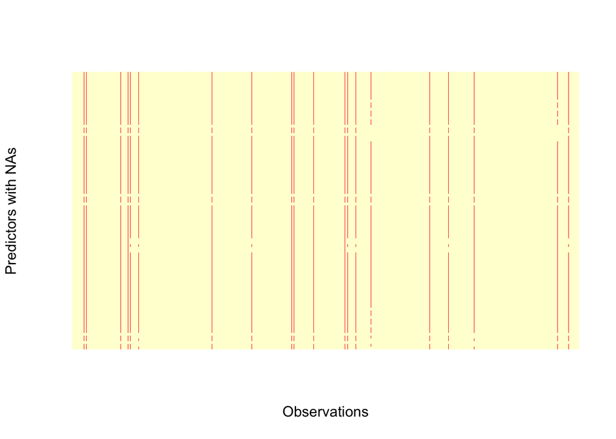

```r
naCols = colnames(train)[colSums(is.na(train)) > 0]
naMap = is.na(train[, naCols])
naMap = matrix(naMap, nrow(train), length(naCols))
image(naMap, axes=FALSE, xlab='Observations', ylab='Predictors with NAs')
```

Here light color means NA value, and dark color means non NA value.

As we can see all variables with NA values have the same pattern and miss values for the most of the observations. Thus let’s just ignore varuables with NA values.

```r
train = train[, !names(train) %in% naCols]
dim(train)
```

```
## [1] 19622    60
```

So now we have only 60 fields.

```r
str(train, list.len=ncol(train))
```

```
## 'data.frame':    19622 obs. of  60 variables:
##  $ X                   : int  1 2 3 4 5 6 7 8 9 10 ...
##  $ user_name           : Factor w/ 6 levels "adelmo","carlitos",..: 2 2 2 2 2 2 2 2 2 2 ...
##  $ raw_timestamp_part_1: int  1323084231 1323084231 1323084231 1323084232 1323084232 1323084232 1323084232 1323084232 1323084232 1323084232 ...
##  $ raw_timestamp_part_2: int  788290 808298 820366 120339 196328 304277 368296 440390 484323 484434 ...
##  $ cvtd_timestamp      : Factor w/ 20 levels "02/12/2011 13:32",..: 9 9 9 9 9 9 9 9 9 9 ...
##  $ new_window          : Factor w/ 2 levels "no","yes": 1 1 1 1 1 1 1 1 1 1 ...
##  $ num_window          : int  11 11 11 12 12 12 12 12 12 12 ...
##  $ roll_belt           : num  1.41 1.41 1.42 1.48 1.48 1.45 1.42 1.42 1.43 1.45 ...
##  $ pitch_belt          : num  8.07 8.07 8.07 8.05 8.07 8.06 8.09 8.13 8.16 8.17 ...
##  $ yaw_belt            : num  -94.4 -94.4 -94.4 -94.4 -94.4 -94.4 -94.4 -94.4 -94.4 -94.4 ...
##  $ total_accel_belt    : int  3 3 3 3 3 3 3 3 3 3 ...
##  $ gyros_belt_x        : num  0 0.02 0 0.02 0.02 0.02 0.02 0.02 0.02 0.03 ...
##  $ gyros_belt_y        : num  0 0 0 0 0.02 0 0 0 0 0 ...
##  $ gyros_belt_z        : num  -0.02 -0.02 -0.02 -0.03 -0.02 -0.02 -0.02 -0.02 -0.02 0 ...
```

[output cut: 46 more lines]

For machine learining algorithm we will need to remove some variables. Obviously X is some kind of observation ID and user_name also not useful for prediction. There are also some other technical fields useless for prediction.

```r
train$X = NULL
train$user_name = NULL
train$cvtd_timestamp = NULL
train$new_window = NULL
```

## Training model

We will use *Random Forest* model for this task. It usually performes very well for classification problems like this one. Also it’s a good choise for the situation when we have a lot of predictors. It deals well with overfitting issues.

To assess model performance we’ll create validation set. After training and evaluating our model we’ll train final model using all the data in the train set.

```r
library(caret)
library(randomForest)
```

```r
inTrain = createDataPartition(train$classe, p=0.8, list=FALSE)

workTrain = train[inTrain,]
validation = train[-inTrain,]

model = randomForest(classe~., data=workTrain)
pred = predict(model, newdata=validation, type="prob")
predClass = predict(model, newdata=validation)
table(predClass, validation$classe)
```

```
##
## predClass    A    B    C    D    E
##         A 1116    1    0    0    0
##         B    0  758    1    0    0
##         C    0    0  683    1    0
##         D    0    0    0  642    0
##         E    0    0    0    0  721
```

Let’s plot ROC curves for all predicted classes and calculate AUC values of our model.

```r
library(ROCR)
```

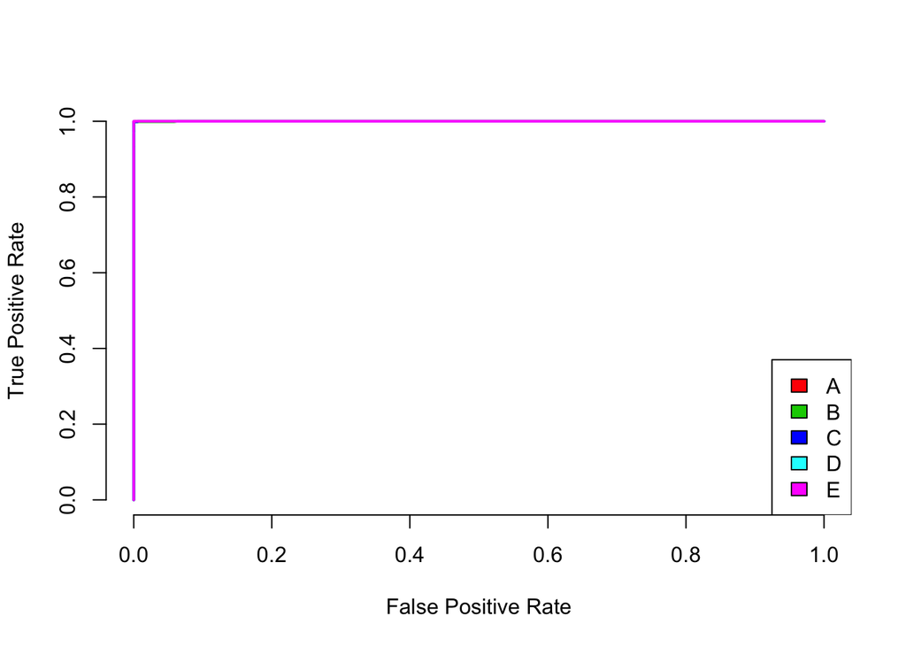

```r
aucs = c()
plot(x=NA, y=NA, xlim=c(0,1), ylim=c(0,1),
     ylab='True Positive Rate',
     xlab='False Positive Rate',
     bty='n')

for (cls in colnames(pred)) {
  rocrPred = prediction(pred[,cls], validation$classe == cls)
  rocrPerf = performance(rocrPred, "tpr", "fpr")

  roc.x = unlist(rocrPerf@x.values)
  roc.y = unlist(rocrPerf@y.values)
  lines(roc.y ~ roc.x, col=which(colnames(pred)==cls)+1, lwd=2)

  auc = performance(rocrPred, "auc")
  auc = unlist(slot(auc, "y.values"))
  aucs[cls] = auc
}
legend("bottomright", legend=colnames(pred), fill=(1:ncol(pred))+1)
```

```r
aucs
```

```
##         A         B         C         D         E
## 0.9999994 0.9999111 0.9999910 0.9999993 1.0000000
```

As we see model performance is very good. So we can expect almost perfect predictions for test set.

## Prediction

To predict classes for test set we retrain model with full training dataset.

```r
model = randomForest(classe~., data=train)
```

```r
test = read.csv("input/pml-testing.csv")
pred = predict(model, newdata=test)
pred
```

```
##  1  2  3  4  5  6  7  8  9 10 11 12 13 14 15 16 17 18 19 20
##  B  A  B  A  A  E  D  B  A  A  B  C  B  A  E  E  A  B  B  B
## Levels: A B C D E
```